# Team 2 - Lab 4

Hidden Markov Models

Lilac, Emma, Mary

May 20, 2025

# Part 1. Hidden Markov Models

For the first part of the homework, we’ll use data from the Pacific Decadal Oscillation (PDO) to ask questions about identifying regimes. This dataset can be accessed via the `rsoi` package. We will look at the winter PDO only. We need to shift the year for Oct-Dec by 1 since Oct-Feb spans 2 calendar years.

```r
pdo <- rsoi::download_pdo()
pdo$Year[which(pdo$Month%in%c("Oct","Nov","Dec"))] <- pdo$Year[which(pdo$Month%in%c("Oct","Nov","Dec"))] + 1
pdo <- dplyr::group_by(pdo, Year) %>%
  dplyr::summarize(winter_pdo = mean(PDO[which(Month %in% c("Oct","Nov","Dec","Jan","Feb"))])) %>%
  dplyr::select(winter_pdo, Year)
# The first year will be missing Oct-Dec
pdo <- pdo[-1,]
```

## 1.1 Fit HMM model

Fit a 2-state HMM to the annual indices of winter PDO. Assume Gaussian errors (default).

```r
# Prepare data for depmixS4
winter_pdo <- data.frame(winter_pdo = pdo$winter_pdo)

# Define HMM with 2 hidden states and Gaussian distribution
hmm_model <- depmix(response = winter_pdo ~ 1,
                    data = winter_pdo,
                    nstates = 2,
                    family = gaussian())

# Fit the model
hmm_fit <- fit(hmm_model, verbose = TRUE)
```

```
## iteration 0 logLik: -104.7085
## iteration 5 logLik: -104.4169
## iteration 10 logLik: -103.0548
## iteration 15 logLik: -97.57758
## iteration 20 logLik: -96.5908
## iteration 25 logLik: -96.24047
## iteration 30 logLik: -96.17209
## iteration 35 logLik: -96.16493
## iteration 40 logLik: -96.16436
## iteration 45 logLik: -96.16432
## converged at iteration 47 with logLik: -96.16431
```

```r
# Summary of the fitted HMM
summary(hmm_fit)
```

```
## Initial state probabilities model
## pr1 pr2
##   1   0
##
## Transition matrix
##         toS1  toS2
## fromS1 0.832 0.168
## fromS2 0.293 0.707
##
## Response parameters
## Resp 1 : gaussian
##     Re1.(Intercept) Re1.sd
## St1          -0.733  0.669
## St2           0.853  0.502
```

## 1.2 Check Stability

Try fitting the model 10-20 times. Does the likelihood seem reasonably stable? (Note `logLik()` gets you the log-likelihood from model fits in R).

```r
# Fit HMM 15 times and store log-likelihoods
set.seed(550)

n_runs <- 15
logLik_values <- numeric(n_runs)

for (i in 1:n_runs) {
  hmm_model <- depmix(response = winter_pdo ~ 1,
                      data = winter_pdo,
                      nstates = 2,
                      family = gaussian())

  hmm_fit <- fit(hmm_model, verbose = FALSE)

  logLik_values[i] <- logLik(hmm_fit)
}
```

```
## converged at iteration 48 with logLik: -96.16431
## converged at iteration 43 with logLik: -96.16431
## converged at iteration 52 with logLik: -96.16431
## converged at iteration 53 with logLik: -96.16431
## converged at iteration 50 with logLik: -96.16431
## converged at iteration 81 with logLik: -96.16431
## converged at iteration 77 with logLik: -96.16431
## converged at iteration 58 with logLik: -96.16431
## converged at iteration 49 with logLik: -96.16431
## converged at iteration 52 with logLik: -96.16431
## converged at iteration 62 with logLik: -96.16431
## converged at iteration 65 with logLik: -96.16431
## converged at iteration 56 with logLik: -96.16431
## converged at iteration 51 with logLik: -96.16431
## converged at iteration 63 with logLik: -96.16431
```

```r
# Print the log-likelihoods
print(logLik_values)
```

```
##  [1] -96.16431 -96.16431 -96.16431 -96.16431 -96.16431 -96.16431 -96.16431
##  [8] -96.16431 -96.16431 -96.16431 -96.16431 -96.16431 -96.16431 -96.16431
## [15] -96.16431
```

Every run converged to the exact same log-likelihood value: -96.16431. The number of iterations varied (e.g., from 43 to 81), but the final log-likelihood was consistent. Therefore, we can conclude that the log-likelihood values are stable.

## 1.3 Transition Matrix and Persistence Probabilities

What is the transition matrix for the best model? What are the persistence probabilities (e.g. probabilities of staying in the same state from step $t$ to $t+1$)?

## 1.4 Plot the predicted values versus year

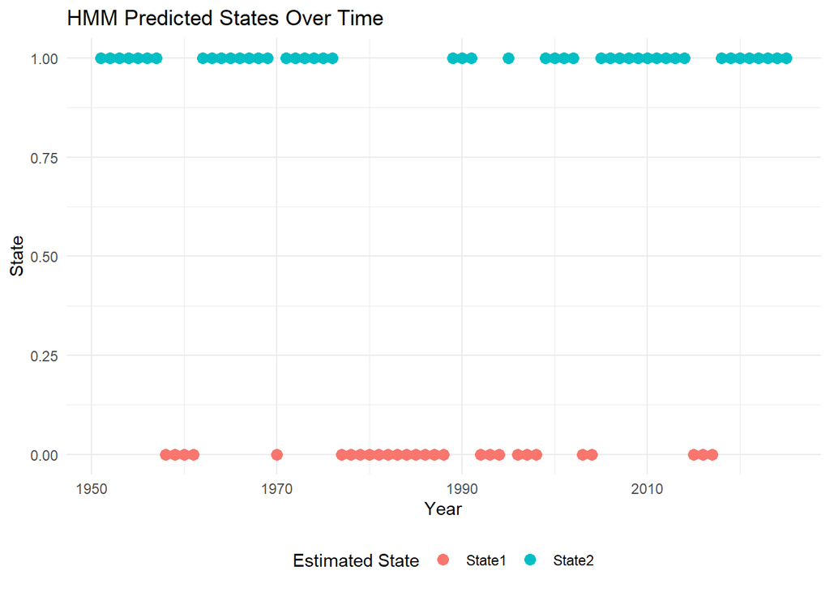

```r
# Combine everything into one data frame
pdo_plot <- pdo
pdo_plot$est_state <- factor(posterior(hmm_fit)$state,
                             levels = c(1, 2),
                             labels = c("State1", "State2"))
pdo_plot <- pdo_plot %>%
  mutate(State = if_else(est_state == "State1", 0, 1))

# Plot
ggplot(pdo_plot, aes(x = Year, y = State, color = est_state)) +
  geom_point(size = 3) +
  labs(title = "HMM Predicted States Over Time",
       x = "Year",
       y = "State",
       color = "Estimated State") +
  theme_minimal() +
  theme(legend.position = "bottom")
```

## 1.5 Plot the posterior probability

Plot the posterior probability of being in the various states from your best model (e.g. probability of being in state 1 over time)

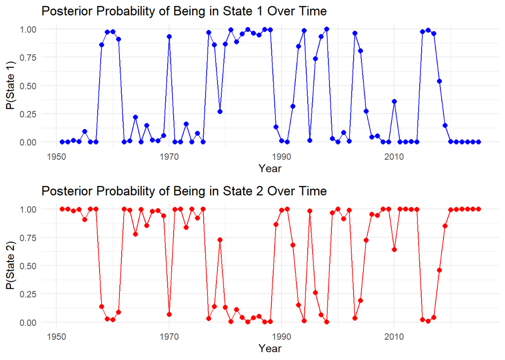

```r
# Extract posterior probabilities and combine with year for plotting
pdo_prob_plot <- data.frame(
  Year = pdo$Year,
  prob_state1 = posterior(hmm_fit)$S1,  # S1 = probability of being in state 1
  prob_state2 = posterior(hmm_fit)$S2   # S2 = probability of being in state 2
)
# Plot probability of being in State 1 over time
p1 <- ggplot(pdo_prob_plot, aes(x = Year, y = prob_state1)) +
  geom_line(color = "blue") +
  geom_point(color = "blue", size = 2) +
  labs(title = "Posterior Probability of Being in State 1 Over Time",
       x = "Year",
       y = "P(State 1)") +
  theme_minimal()

# Plot probability of being in State 2 over time
p2 <- ggplot(pdo_prob_plot, aes(x = Year, y = prob_state2)) +
  geom_line(color = "red") +
  geom_point(color = "red", size = 2) +
  labs(title = "Posterior Probability of Being in State 2 Over Time",
       x = "Year",
       y = "P(State 2)") +
  theme_minimal()

ggpubr::ggarrange(p1, p2, nrow = 2)
```

## 1.6 Long-run probability

What is the long-run probability that the PDO is in state 1 versus state 2? You can calculate this from the transition matrix. There is an analytical solution for this (a bit of googling will find it). Or you can run a `for` loop to find it. Let $p_1$ be the probability that PDO is in state 1 and $p_2$ be the probability that PDO is in state 2. Note $p_1 + p_2 = 1$. If $P$ is the transition matrix (in Q3),

$$\begin{bmatrix}p_1&p_2\end{bmatrix}_n =
\begin{bmatrix}p_1&p_2\end{bmatrix}_{n-1} P$$
Note this is a 1x2 matrix times a 2x2 matrix on the right. Start with $p_1=1$ and $p_2=0$, say. Run a `for` loop until

$$\begin{bmatrix}p_1&p_2\end{bmatrix}_n \approx
\begin{bmatrix}p_1&p_2\end{bmatrix}_{n-1}$$
That $\begin{bmatrix}p_1&p_2\end{bmatrix}_n$ is the long-run probability in each state.

```r
# Extract the transition matrix from your best model
n_states <- 2
trans_mat <- matrix(NA, nrow = n_states, ncol = n_states)

for (i in 1:n_states) {
  # Access transition model for state i
  trans_model <- hmm_fit@transition[[i]]

  # Get parameters (probabilities to all states from state i)
  trans_mat[i, ] <- getpars(trans_model)
}

# Initialize probabilities
p <- c(1, 0)  # Start: 100% in state 1

# Iterate until convergence
threshold <- 1e-8
max_iter <- 1000

for (i in 1:max_iter) {
  p_new <- p %*% trans_mat  # Matrix multiplication
  if (sum(abs(p_new - p)) < threshold) {
    break
  }
  p <- p_new
}

# Display result
colnames(p) <- c("State 1", "State 2")
p
```

```
##        State 1   State 2
## [1,] 0.3650873 0.6349127
```

```r
## ---- Analytic stationary distribution  ----
P <- trans_mat                      # 2×2 transition matrix from Q 1.3
stat_vec <- eigen(t(P))$vectors[,1] # left eigen-vector for λ = 1
stat_vec <- Re(stat_vec / sum(stat_vec))

tibble(State = c("1","2"),
       Stationary_Prob = round(stat_vec, 3)) %>%
  knitr::kable(
    caption = "Analytic stationary distribution (should match loop result)"
  )
```

Analytic stationary distribution (should match loop result)

| State | Stationary_Prob |
| --- | --- |
| 1 | 0.365 |
| 2 | 0.635 |

In the long run, the PDO is expected to be:

- In State 1 about 36.5% of the time
- In State 2 about 63.5% of the time

```r
# ---- Quick AIC comparison: 1-, 2-, 3-state HMMs ----
set.seed(550)

# 1-state model
mod1 <- depmix(response = winter_pdo ~ 1,
               data     = winter_pdo,
               nstates  = 1,
               family   = gaussian()) %>%
        fit(verbose = FALSE)
```

```
## converged at iteration 1 with logLik: -104.7535
```

```r
# 2-state model is the one we already fitted (hmm_fit)
mod2 <- hmm_fit   # just a handy alias

# 3-state model
mod3 <- depmix(response = winter_pdo ~ 1,
               data     = winter_pdo,
               nstates  = 3,
               family   = gaussian()) %>%
        fit(verbose = FALSE)
```

```
## converged at iteration 132 with logLik: -92.59892
```

```r
# Build comparison table
knitr::kable(
  data.frame(Model = c("1-state", "2-state", "3-state"),
             AIC   = c(AIC(mod1), AIC(mod2), AIC(mod3))),
  caption = "AIC comparison for alternative state counts"
)
```

AIC comparison for alternative state counts

| Model | AIC |
| --- | --- |
| 1-state | 213.5070 |
| 2-state | 206.3286 |
| 3-state | 213.1978 |

# Part 2. Fitting Multivariate HMMs

## Data

As part of the California Current Integrated Ecosystem Report, NOAA scientists do annual updates of [stoplight charts for ecosystem indicators](https://www.fisheries.noaa.gov/west-coast/science-data/ocean-conditions-indicators-trends).

Describe what plankton groups and covariates you used and indicate any temporal subsetting you chose. Also describe any standardization, centering or scaling that was used.

## Load the data

One of the columns divides indicators into groups (e.g. Local Physical, Local Biological, etc).

```r
library(readr)           # already loaded above
library(dplyr)

stoplight <- read_csv(here::here("Lab-4", "stoplight.csv")) %>%
  rename(`Ecosystem Indicators` = 1)   # <- rename first column immediately
```

## Wrangle the data

```r
library(dplyr)
#Read in the data
stoplight <- read_csv("stoplight.csv") %>%
  rename(`Ecosystem Indicators` = 1)
#Going to model Nearshore ichthyoplankton and juvenile chinook as two biological indicators
#Subset the data to only include rows 13 and 15

dat <- stoplight %>%  filter(!row_number() %in% c(1:12,14, 16:23))

#Need to convert from wide to long
library(tidyr)
library(atsalibrary)
```

```r
library(ggplot2)
#install.packages("hmmTMB")
library(hmmTMB)
#install.packages("depmixS4")
library(depmixS4)
dat_long <- dat %>%
  pivot_longer(cols = -c("Ecosystem Indicators", "Type"), names_to = "year", values_to = "vals")

#Remove the first digit in the year column
dat_long$year <- gsub("X", "", dat_long$year)

#Convert to the correct wide
dat_wide <- dat_long %>%
  dplyr::select(-Type) %>%
  tidyr::pivot_wider(names_from = `Ecosystem Indicators`, values_from = vals)

dat_wide$time <- dat_wide$year
dat_wide$time <- as.numeric(dat_wide$time)
dat_wide$year <- NULL
dat_wide$Nearshore_Ichthyoplankton <- as.numeric(dat_wide$Nearshore_Ichthyoplankton)
dat_wide$Chinook_salmon_juv <- as.numeric(dat_wide$Chinook_salmon_juv)
```

## General tasks

We have decided to use the juvenile chinook data and the nearshore icthyoplankton data. This should be an interesting comparison because of the potential links as predator/prey in the nearshore environment during the outmigration of salmon. In addition to potentially preying on nearshore ichthyoplankton, juvenile chinook may also be preying on other species, which could complicate the relationship.

## Methods

Using the nearshore ichthyoplankton and juvenile chinook data, we fit a 2- state HMM model. After analyzing the fit of the 2 state multivariate HMM, we will either run a 3- state HMM on the same species, or use a univariate HMM on the data if there is a complication or no convergence on states.

```r
# Fit a 2-state model to the ichthyoplankton and juvenile chinook data
set.seed(123)
hidden2 <- MarkovChain$new(data = dat_wide, n_states = 2)
dists <- list(Nearshore_Ichthyoplankton = "norm", Chinook_salmon_juv = "norm")
par0 <- list(Nearshore_Ichthyoplankton = list(mean = c(0,2), sd = c(0.5, 0.5)),
             Chinook_salmon_juv = list(mean = c(0,1), sd = c(0.1, 0.1)))
obs_model2s <- Observation$new(data = dat_wide,
                             dists = dists,
                             n_states = 2,
                             par = par0)
```

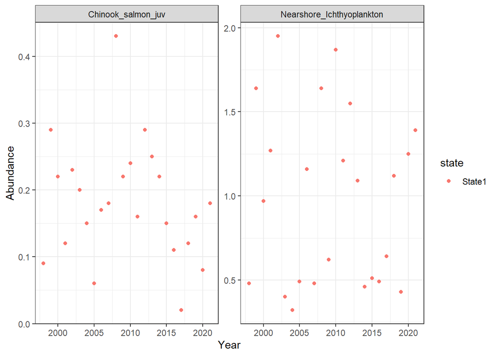

```r
hmm2s <- HMM$new(obs = obs_model2s,
               hid = hidden2)
hmm2s$fit(silent=TRUE)


#Check the fit
states2s <- hmm2s$viterbi()
dat_wide$state <- states2s

dat_wide$state <- factor(paste0("State", hmm2s$viterbi()))
# Ensure 'state' is treated as a factor for color mapping
dat_wide$state <- factor(dat_wide$state)

# Reshape to long format
dat_long2s <- dat_wide %>%
  pivot_longer(cols = c(Nearshore_Ichthyoplankton, Chinook_salmon_juv),
               names_to = "species",
               values_to = "abundance")

# Plot with facets
ggplot(dat_long2s, aes(x = time, y = abundance, col = state)) +
  geom_point() +
  facet_wrap(~species, scales = "free_y") +
  ylab("Abundance") +
  xlab("Year") +
  theme_bw()
```

```r
#2 state doesn't identify any particular trend, however visually it appears as though the nearshore ichys may have a second state that is not resolved in the model. Going to run a univariate to attempt to inestigate.

# Fit a 2-state univariate HMM for Nearshore Ichthyoplankton
set.seed(123)

# Create hidden Markov chain with 2 states
hidden2NI <- MarkovChain$new(data = dat_wide, n_states = 2)

# Specify distribution for the single variable
dists <- list(Nearshore_Ichthyoplankton = "norm")
par0 <- list(Nearshore_Ichthyoplankton = list(mean = c(0, 2), sd = c(0.5, 0.5)))

obs_model2sNI <- Observation$new(data = dat_wide,
                               dists = dists,
                               n_states = 2,
                               par = par0)
```

[output not shown]

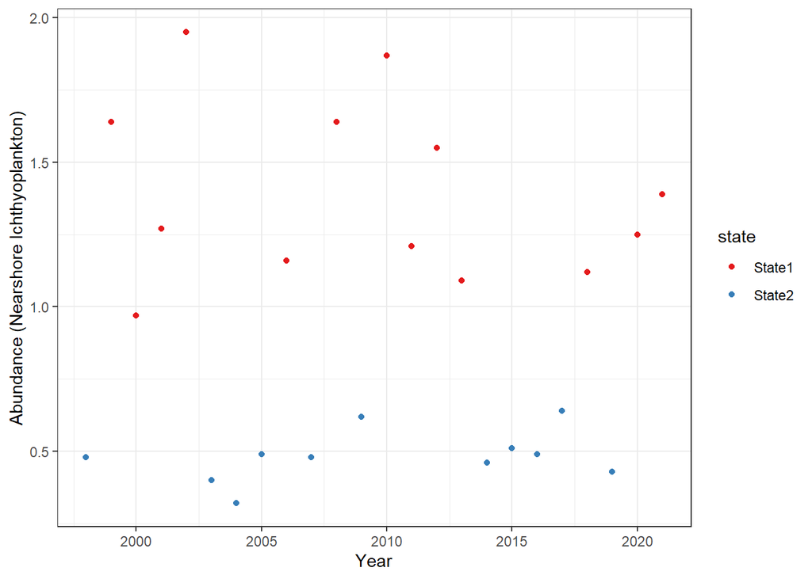

```r
hmm2sNI <- HMM$new(obs = obs_model2sNI, hid = hidden2NI)
hmm2sNI$fit(silent = TRUE)

dat_wide$state <- factor(paste0("State", hmm2sNI$viterbi()))

# Plot results
ggplot(dat_wide, aes(x = time, y = Nearshore_Ichthyoplankton, col = state)) +
  geom_point() +
  ylab("Abundance (Nearshore Ichthyoplankton)") +
  xlab("Year") +
  theme_bw() +
  scale_color_brewer(palette = "Set1")
```

```r
## ---- Quick AIC table: 2–3 state multivariate HMMs ----
library(purrr)
```

```r
# Define distributions for both indicators
dists <- list(
  Nearshore_Ichthyoplankton = "norm",
  Chinook_salmon_juv = "norm"
)

# Dynamic parameter constructor
make_par0 <- function(k) {
  list(
    Nearshore_Ichthyoplankton = list(
      mean = seq(0, 2, length.out = k),
      sd   = rep(0.5, k)
    ),
    Chinook_salmon_juv = list(
      mean = seq(0, 1, length.out = k),
      sd   = rep(0.1, k)
    )
  )
}

# Fit HMM using hmmTMB-compatible structure
fit_mv_hmm <- function(k){
  hidden <- MarkovChain$new(data = dat_wide, n_states = k)
  par0_k <- make_par0(k)
  obs    <- Observation$new(data = dat_wide,
                            dists = dists,
                            n_states = k,
                            par = par0_k)
  mod    <- HMM$new(obs = obs, hid = hidden)
  mod$fit(silent = TRUE)   # fit in-place
  return(mod)              # return the fitted model object
}

# Compare 2- and 3-state models
mv_models <- map(2:3, fit_mv_hmm)
```

[output not shown]

[output not shown]

```r
# Build AIC table
tibble(
  States = 2:3,
  AIC = map_dbl(mv_models, AIC)

) %>%
  knitr::kable(caption = "Multivariate HMM: AIC for 2- and 3-state models")
```

Multivariate HMM: AIC for 2- and 3-state models

| States | AIC |
| --- | --- |
| 2 | 7.589707 |
| 3 | 25.589707 |

## Results

Running a 2-state multivariate HMM on the ichthyoplankton and juvenile chinook converged on only one state between the two species. When plotted, the juvenile salmon appeared to have only one state, however when viewing the nearshore ichthyoplankton data, it appears as though there may be a second state that is not fully resolved in the model. Upon use of a univariate 2 state HMM, the nearshore ichthyoplankton data converged on two states successfully.

To assess model complexity, we fit a 3-state multivariate HMM and compared AIC values. The 2-state model had a lower AIC, indicating better model fit with fewer parameters, and thus was retained.

Because the nearshore ichthyoplankton may still show distinct regimes not fully captured in the multivariate model, we fit a separate univariate 2-state HMM to that species alone. This model did successfully resolve two distinct states in the ichthyoplankton time series.

## Discussion

The interesting findings of the multivariate HMM and the convergence on 2 states when investigating only the nearshore ichthyoplankton data suggest that there may be a relationship between the two species that is not fully captured in the multivariate model. The juvenile chinook salmon may be responding to the nearshore ichthyoplankton data, but the relationship may not be strong enough to resolve two states in the multivariate model. This is somewhat what we would expect ecologically, as juvenile chinook may act as a predator of nearshore ichthyoplankton during the salmon outmigration, and thus they may reflect (to some degree) the dynamics of the nearshore ichythoplankton, but there are likely other prey items involved that complicate this simple analysis.

While we initially explored a 2-state multivariate HMM, we also fit a 3-state version to assess whether additional latent structure could better capture the species dynamics. However, the AIC comparison showed that the 3-state model did not improve model fit relative to the 2-state model. This suggests that the additional complexity of a third hidden state is not justified by the data, and that a 2-state model likely captures the dominant regime structure present in the ichthyoplankton and juvenile Chinook data. This result further supports the idea that juvenile Chinook responses may not strongly co-vary with nearshore ichthyoplankton in a way that would produce clear, shared state-switching behavior at this scale.

# Team contributions

Lilac completed the code and interpretation in Part 1. Emma completed the analysis, coding, and writing for Part 2. Mary contributed to the final model selection analysis, AIC comparison.